# The Laplacian in RL: Learning Representations with Efficient Approximations

This is a summary of the ICLR paper [The Laplacian in RL: Learning Representations with Efficient Approximations](https://openreview.net/forum?id=HJlNpoA5YQ) by Yifan Wu (yw4@andrew.cmu.edu), George Tucker, and Ofir Nachum.

Summary by [Charley Wu](https://charleywu.github.io) with no relation to the author of the actual paper.

# Generalization in RL

The RL framework by Sutton and Barto (2018) commonly represents the environment in the form of a Markov Decision Process (MDP)

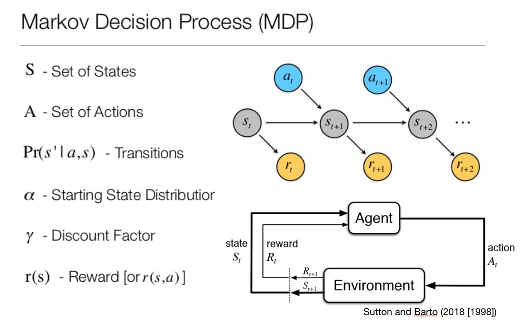

An MDP is a type of graph representation, where nodes represent states and edges are transitions between states. Selecting actions allow an agent to transition across the graph structure. While building a representation of the transition structure (i.e., model-based RL) is not always necessary, it can help to generalize limited observations of reward to other states.

[figure not shown]

## Successor Representation

Dayan (1993) showed that the value function of a TD-learning agent can be decomposed into a linear combination of state transitions $M(s,s')$ and learned reward representation $R(s')$:
$$\begin{equation}
V(s) = \sum_{s'}M(s,s')R(s')
\end{equation}$$
This matrix of state representations $M(s,s')$ is the SR, where each element $m_{jk}$ encodes the similarity of successor states for states $s_j$ and $s_k$ (Dayan 1993; Gershman 2018). Intuitively, the SR can be understood as a similarity measure based on expectations of future state transitions, rather than the singular features of each state. Thus, rewards generalize based on future transition probability.

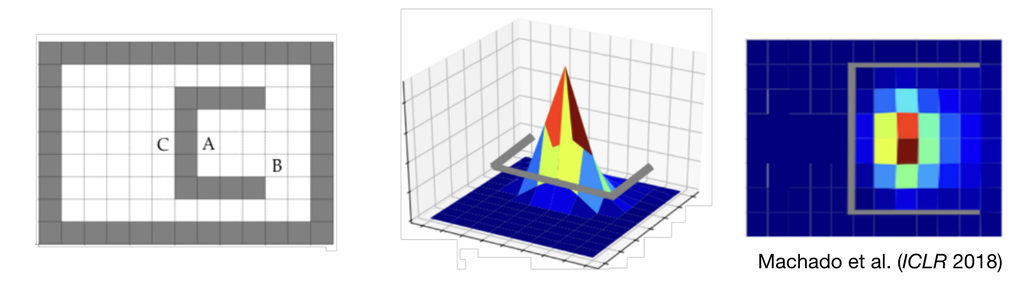

Assume A is a reward state. Because of the obstacle in the environment, the similarity $M(A,C)$ is less than $M(A,B)$, since moving from C–>A requires more steps than B–>A, even though the euclidean distance between A and C is less. From Machado et al. (2018)

### Computing the SR

When the transition structure of the task is known , the SR can be computed in closed form:
$$\begin{equation}
M(s,s') = (I - \gamma T)^{-1},
\end{equation}$$

where $I$ is the identity matrix, $\gamma$ is the TD discount factor, and $T$ is the transition matrix where $t_{jk}=P(s'=k|s=j)$. A common approach is to assume a random walk over the state space:
$$\begin{equation}
T = D^{-1}A
\end{equation}$$
where $D$ is the degree matrix and $A$ is the adjacency matrix (more on that later).

But if the transition matrix $T$ is not yet known, the SR can still be learned online through prediction error learning:
$$\begin{equation}
\hat{M}_{t+1}(s_t,s') = \hat{M}_{t}(s_t,s') + \alpha \left[\delta(s_t=s') + \gamma \hat{M}_{t+1}(s_t,s') - \hat{M}_{t}(s_t,s')\right]
\end{equation}$$

However, this may still require:

- knowing all states $s \in S$
- having experienced many transitions between each coneccted $s$ and $s'$ pair

**The main goal of this paper is to provide an efficient approximate solution for computing state similarity**

## The Graph Laplacian

So far we have talked about the SR, but this paper talks about Graph Laplacian. How are these concepts related?

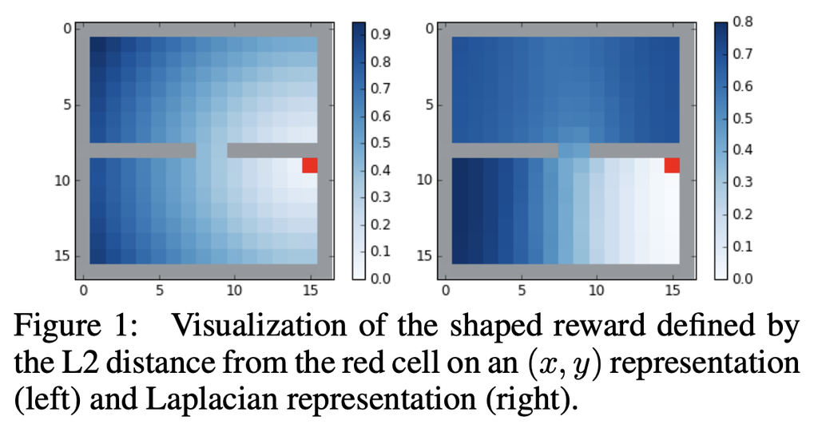

It turns out that the Graph Laplacian direct equivalencies to the SR (see Stachenfeld, Botvinick, and Gershman 2014), where both capture a representation of the transition structure of a graph.

Let’s try out some examples

```r
#Load packages
packages <- c('dplyr', "ggplot2", 'GGally', 'network', "RColorBrewer", "igraph", 'matrixcalc', 'Matrix', 'lattice', 'jsonlite', 'viridis')
invisible(lapply(packages, require, character.only = TRUE)) #load packages

#Generate a graph from a news media dataset, where node size is based on audience (millions), and edges are average mentions (undirected)
nodes <- read.csv("data/Dataset1-Media-Example-NODES.csv", header=T, as.is=T)
links <- read.csv("data/Dataset1-Media-Example-EDGES.csv", header=T, as.is=T)
g <- graph_from_data_frame(d=links, vertices=nodes, directed=T)
g <- simplify(g, remove.multiple = F, remove.loops = T) #remove loops
g <- as.undirected(g) #convert to undirected graph
E(g)$weight <- E(g)$weight/max(E(g)$weight) #normalize edge weights
V(g)$audience.size <- V(g)$audience.size/max(V(g)$audience.size) #also normalize node sizes

ggnet2(g, node.size =V(g)$audience.size , color =rainbow(length(V(g))), label = V(g)$media, edge.size ='weight') + theme(legend.position='none')
```

[output not shown]

The Graph Laplacian $L$ is actually really easy to calculate if you know the transition structure of the graph.
$$\begin{equation}
L = D-A
\end{equation}$$
where $D$ is the Degree matrix with the (weighted) degree of each node along the diagonal and $A$ is the (weighted) adjacency matrix

```r
palf <- colorRampPalette(c("white", "black")) #color palette

#Degree matrix
D <- diag(strength(g))
rownames(D) <- V(g)$media
colnames(D) <- V(g)$media
heatmap(D[,17:1], Rowv =NA, Colv = NA, col = palf(100), scale="none", margins=c(10,10) )

#Adjacency matrix (weighted if graph is also weighted)
if(is_weighted(g)){
  A <- as_adjacency_matrix(g,  attr="weight", sparse=F)
}else{
  A <- as_adjacency_matrix(g, sparse=F)
}

rownames(A) <- V(g)$media
colnames(A) <- V(g)$media
heatmap(A[,17:1], Rowv =NA, Colv = NA, col = palf(100), scale="none", margins=c(10,10) )


#Graph Laplacian

L = D- A
heatmap(L[,17:1], Rowv =NA, Colv = NA, col = palf(100), scale="none", margins=c(10,10) )
```

[output not shown]

### Quick caveat: There are a number of different Laplacians that are easy to confuse.

```r
#Normalized Laplacian
I <- diag(rep(1,length(V(g)))) #identity matrix
L_normed <- I - sqrt(solve(D))%*%A%*%sqrt(solve(D))
heatmap(L_normed[,17:1], Rowv =NA, Colv = NA, col = palf(100), scale="none", margins=c(10,10) )
```

[output not shown]

```r
#Row-normalized Laplacian
L_rownorm <- I - solve(D)%*%A
heatmap(L_rownorm[,17:1], Rowv =NA, Colv = NA, col = palf(100), scale="none", margins=c(10,10) )
```

[output not shown]

## Eigenvectors of the Graph Laplacian

What we’re primarily interested in are the Eigenvectors of the Graph Laplacian, since these provide us with a compressed representation of the state dynamics. For example, the $d$ smallest eigenvectors of the Laplacian provide an embedding for each state $s\in S$ in $\mathbb{R}^d$, where distances in this reduced representation capture state similarity.

However, performing the eigenvector decopompoisition can be computationally expensive for large graphs.

# References

Dayan, Peter. 1993. “Improving Generalization for Temporal Difference Learning: The Successor Representation.” *Neural Computation* 5 (4). MIT Press: 613–24.

Gershman, Samuel J. 2018. “The successor representation: Its computational logic and neural substrates.” *Journal of Neuroscience* 38. Soc Neuroscience: 7193–7200.

Machado, Marlos C., Clemens Rosenbaum, Xiaoxiao Guo, Miao Liu, Gerald Tesauro, and Murray Campbell. 2018. “Eigenoption Discovery Through the Deep Successor Representation.” In *Proceedings of the International Conference on Learning Representations (ICLR)*.

Stachenfeld, Kimberly L, Matthew Botvinick, and Samuel J Gershman. 2014. “Design Principles of the Hippocampal Cognitive Map.” In *Advances in Neural Information Processing Systems 27*, edited by Z. Ghahramani, M. Welling, C. Cortes, N. D. Lawrence, and K. Q. Weinberger, 2528–36.

Sutton, Richard S, and Andrew G Barto. 2018. *Reinforcement learning: An introduction*. Second. MIT press.

Wu, Yifan, George Tucker, and Ofir Nachum. 2018. “The Laplacian in Rl: Learning Representations with Efficient Approximations.” *arXiv Preprint arXiv:1810.04586*.